# Praca domowa 2

Martyna Sadowska

## Dane

Dane wykorzystane w Pracy domowej 2 opisują wycenę nieruchmości. Każda obserwacja jest pewną nieruchmością, która posiada informacje takie jak powierzchnia, liczba pokoi, liczba łazienek i wiele więcj. Opis wszystkich kolumn w pliku `README.md`.

## Zadanie 1

Jak wygląda rozkład ceny nieruchomości w poszczególnych kodach pocztowych na przestrzeni lat? Rozważamy kody pocztowe, które mają więcej niż 280 posiadłości.

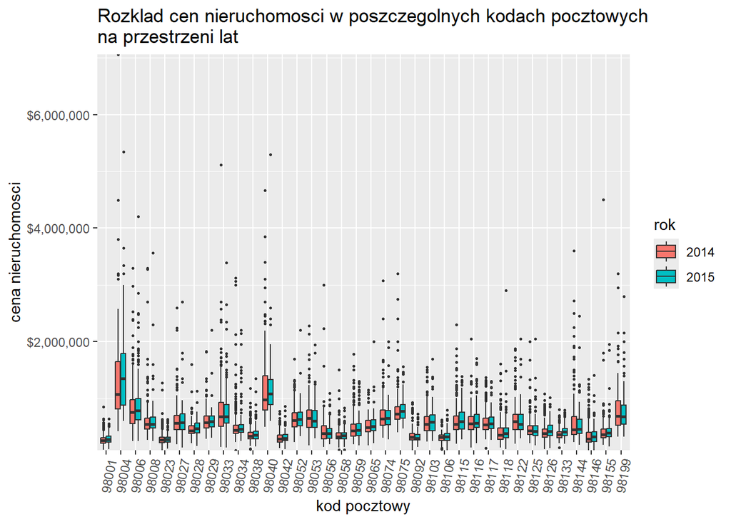

```r
# Tu umieść kod do wygenerowania odpowiedzi do zadania.

zipcodes_1 <- df %>% group_by(zipcode) %>% summarise(count = n()) %>%
  filter(count > 280)
df_1 <- df %>% mutate(year = substr(date, 1, 4)) %>%
  filter(zipcode %in% zipcodes_1$zipcode)
plot_1 <- df_1 %>%
  ggplot(aes(x = factor(zipcode), y = price, fill = year)) + geom_boxplot(outlier.size = 0.5) +
  scale_x_discrete(guide = guide_axis(angle = 80)) +
  scale_y_continuous(labels = dollar, expand = c(0, 0)) +
  labs(x = "kod pocztowy", y = "cena nieruchomosci", fill = "rok",
       title = "Rozklad cen nieruchomosci w poszczegolnych kodach pocztowych\nna przestrzeni lat")
plot_1
```

```r
#plot_1_2 <- df_1 %>% group_by(zipcode, year) %>% summarise(mean_price = mean(price)) %>%
#  ggplot(aes(x = factor(zipcode), y = mean_price, fill = year)) + geom_col(position = "dodge") +
#  scale_x_discrete(guide = guide_axis(angle = 80)) +
#  scale_y_continuous(labels = dollar, expand = c(0, 0)) +
#  labs(x = "kod pocztowy", y = "srednia cena nieruchomosci", fill = "rok",
#       title = "Srednie ceny nieruchomosci w poszczegolnych kodach pocztowych\nna przestrzeni lat")
#plot_1_2
```

**Komentarz:** Ceny w roku 2015 lekko wzrosły. W różnych kodach pocztowych ceny są bardzo zróżnicowane.

## Zadanie 2

Czy jest różnica w rozkładzie ceny nierchomości od powierzchni mieszkalnej uwzględniając podział na nieruchomości z piwnicą i bez?

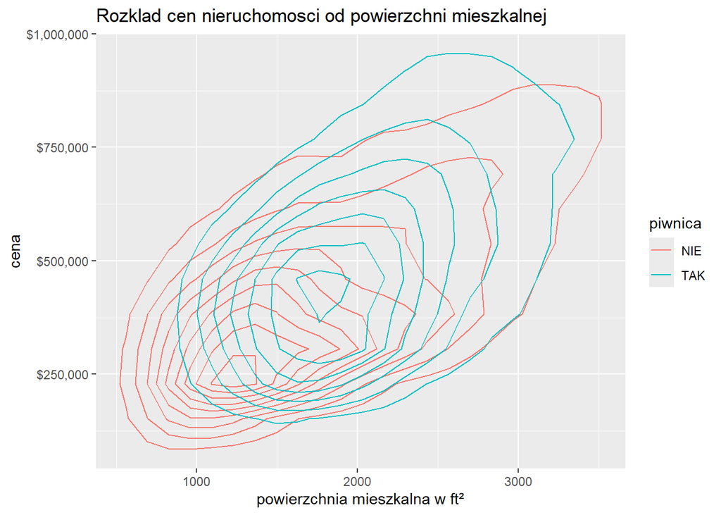

```r
# Tu umieść kod do wygenerowania odpowiedzi do zadania.

df_2 <- df %>% mutate(basement = ifelse(sqft_basement > 0, "TAK", "NIE"))
plot_2 <- df_2 %>% ggplot(aes(x = sqft_living, y = price, color = basement)) +
  geom_density_2d(bins = 10) + scale_y_continuous(labels = dollar) +
  labs(title = "Rozklad cen nieruchomosci od powierzchni mieszkalnej",
       x = "powierzchnia mieszkalna w ft²", y = "cena", color = "piwnica")
plot_2
```

```r
#df_2_2 <- df %>% mutate(basement = ifelse(sqft_basement > 0, "TAK", "NIE"),
#                        price_per_sqft = price / sqft_living)
#plot_2_2 <- df_2_2 %>% ggplot(aes(x = basement, y = price_per_sqft)) +
#  geom_violin() + scale_y_continuous(labels = dollar) +
#  labs(title = "Cena za stope kwadratowa z podzialem na nieruchomosci z piwnica i bez",
#       x = "piwnica", y = "cena za stope kwadratowa")
#plot_2_2
```

**Komentarz:** Nieruchomości z piwnicą mają nieco wyższe ceny (głównie przy większej powierzchni mieszkalnej) niż te bez piwnicy. Sama powierzchnia mieszkalna też jest większa, gdy nieruchomość posiada piwnicę.

## Zadanie 3

Jaka jest zależność pomiędzy jakością wykończenia nieruchomości a liczbą pięter?

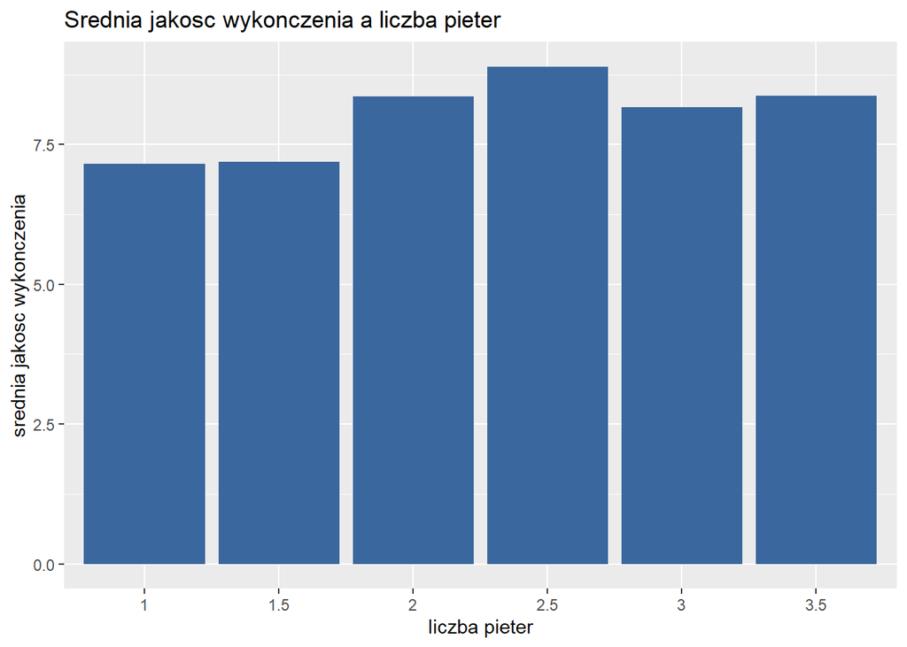

```r
# Tu umieść kod do wygenerowania odpowiedzi do zadania.

df_3 <- df %>%
  group_by(floors) %>%
  summarise(mean_grade = mean(grade))
plot_3 <- df_3 %>%
  ggplot(aes(x = factor(floors), y = mean_grade)) + geom_col(fill = "#3A679E") +
  labs(title = "Srednia jakosc wykonczenia a liczba pieter",
       x = "liczba pieter", y = "srednia jakosc wykonczenia")
plot_3
```

**Komentarz:** Jakość wykończenia jest średnio większa dla nieruchomości z większą liczbą pięter niż 1, 1.5. Najlepsza jakość wykończenia jest dla nieruchomości, które mają 2.5 piętra.

## Zadanie 4

Jaka jest zależność między powierzchnią mieszkalną nieruchomości a powierzchnią gruntu w podziale na liczbę sypialni?

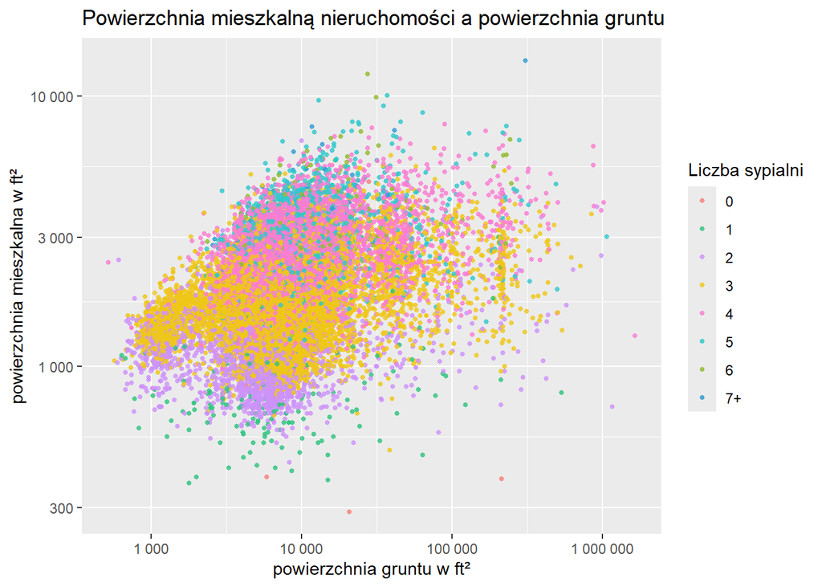

```r
# Tu umieść kod do wygenerowania odpowiedzi do zadania.

df_4 <- df %>% mutate(bedrooms_category = ifelse(bedrooms > 6, "7+", as.character(bedrooms)))
plot_4 <- df_4 %>% ggplot(aes(x = sqft_lot, y = sqft_living, color = bedrooms_category)) +
  geom_point(alpha = 0.8, size = 1) + scale_y_log10(labels = label_number()) +
  scale_x_log10(labels = label_number()) +
  scale_color_manual(values = c("0" = "#f68179", "1" = "#30C380",
    "2" = "#ce92fb", "3" = "#EFC718", "4" = "#fb7dd2",
    "5" = "#2fc8cc", "6" = "#92ba2f", "7+" = "#309CD4"
  )) +
  labs(color = "Liczba sypialni", x = "powierzchnia gruntu w ft²", y = "powierzchnia mieszkalna w ft²",
       title = "Powierzchnia mieszkalną nieruchomości a powierzchnia gruntu")
plot_4
```

**Komentarz:** Powierzchnia mieszkalna rośnie razem z powierzchnią gruntu. Im więcej sypialni, tym większa jest powierzchnia mieszkalna.

## Zadanie 5

Rozważmy tylko nieruchomości, które miały remont. W której dekadzie było najwięcej przeprowadzonych remontów? Czy w poszczególnych dekadach jest porównywalny procent nieruchmości dla każdej wartości miary jakości i wykończenia nieruchomości?

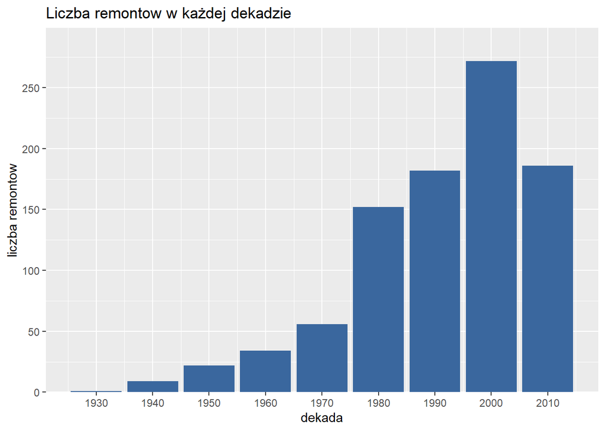

```r
# Tu umieść kod do wygenerowania odpowiedzi do zadania.

df_5 <- df %>% filter(yr_renovated != 0) %>% mutate(decade = yr_renovated %/% 10 * 10)

plot_5_1 <- df_5 %>% group_by(decade) %>% summarise(count = n()) %>%
  ggplot(aes(x = decade, y = count)) + geom_col(fill = "#3A679E") +
  labs(title = "Liczba remontow w każdej dekadzie", x = "dekada", y = "liczba remontow") +
  scale_y_continuous(expand = expansion(mult = c(0, 0.1)), breaks = seq(from = 0, to = 300, by = 50)) +
  scale_x_continuous(breaks = sort(unique(df_5$decade)))
plot_5_1
```

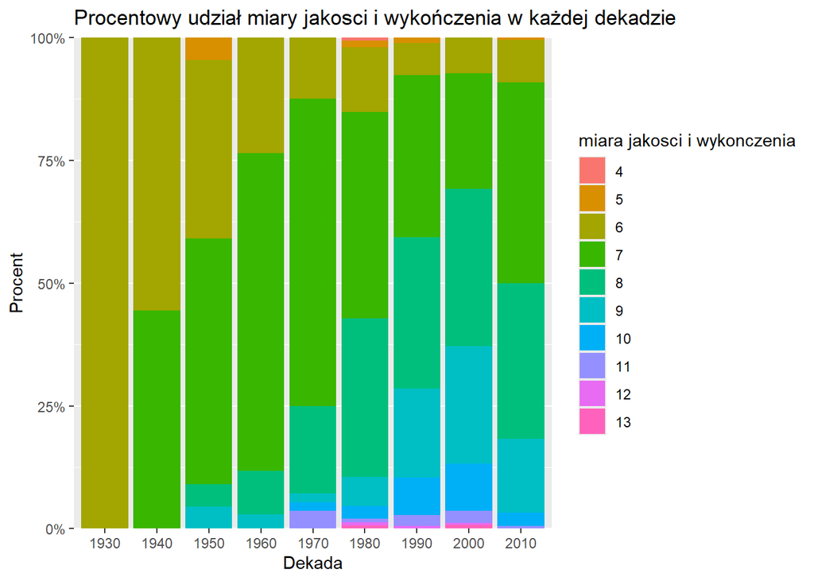

```r
plot_5_2 <- df_5 %>% group_by(decade, grade) %>% summarise(count = n()) %>%
  mutate(percentage = count / sum(count) * 100,
         decade = factor(decade, levels = sort(unique(decade)))) %>%
  ggplot(aes(x = decade, y = percentage, fill = factor(grade))) +
  geom_bar(stat = "identity", position = "stack") +
  labs(title = "Procentowy udział miary jakosci i wykończenia w każdej dekadzie",
       x = "Dekada", y = "Procent", fill = "miara jakosci i wykonczenia") +
  scale_y_continuous(labels = percent_format(scale = 1), expand = c(0, 0))
plot_5_2
```

**Komentarz:** Najwięcej remontów przeprowadzono w latach dwutysięcznych. Do lat dwutysięcznych coraz większy procent remontów stanowią te o wyższej mierze jakości i wykończenia. W kolejnej dekadzie remonty lekko obniżają swoją miarę jakości.

## Zadanie 6

Jak prezentuje się wartość minimalna, średnia i maksymalna ceny nieruchmości w podziele na rok budowy nieruchomości.

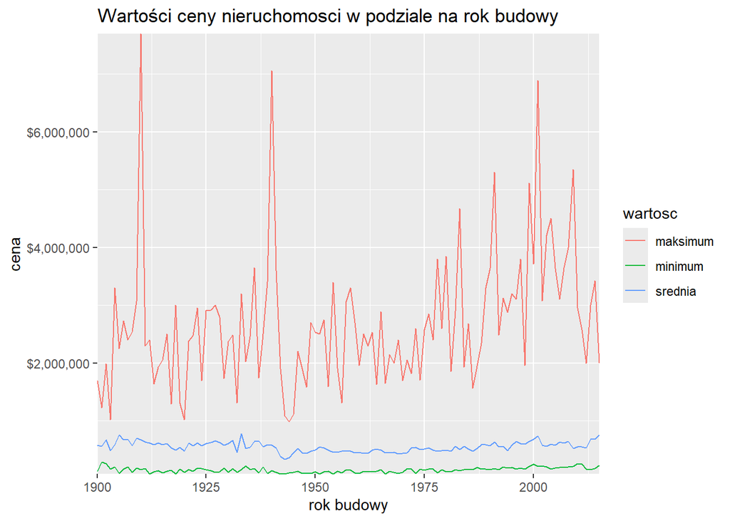

```r
# Tu umieść kod do wygenerowania odpowiedzi do zadania.

df_6 <- df %>% group_by(yr_built) %>%
  summarise(minimum = min(price), srednia = mean(price), maksimum = max(price)) %>%
  pivot_longer(cols = c(minimum, srednia, maksimum), names_to = "wartosc", values_to = "price")
plot_6 <- df_6 %>% ggplot(aes(x = yr_built, y = price, color = wartosc)) + geom_line() +
  labs(x = "rok budowy", y = "cena", title = "Wartości ceny nieruchomosci w podziale na rok budowy") +
  scale_y_continuous(labels = dollar, expand = c(0, 0)) + scale_x_continuous(expand = c(0, 0))
plot_6
```